# Exploratory Data Analysis of City of Austin Water Quality

### **Research Question 3:** Among the site types streams, lakes, and springs, is there a difference between what water quality tests are conducted and the number of tests and the site type?

```r
# Visualization 8 for research question 3

water_quality_test_filtered <- water_quality_sampling_data_tidy |>
    filter(SITE_TYPE %in% c('Spring', 'Lake', 'Stream'))
table(water_quality_test_filtered$SITE_TYPE, water_quality_test_filtered$PARAM_TYPE)
```

```
##
##          Alkalinity/Hardness/pH Bacteria/Pathogens Carbon Chlorinated
##   Lake                    11404               2374    357         309
##   Spring                   6761               8001   2016        1110
##   Stream                  17425              20730   2902         281
##
##          Fungicides Hydrocarbons Insecticides Major Ions Metals Nutrients
##   Lake            8          350            4       3514   2262     20879
##   Spring        198         1423          301      15557  13075     13263
##   Stream        232         3690          149       6853  10532     50723
##
##          Oxygen Solids/Conductivity
##   Lake    11077               14559
##   Spring   6106                6926
##   Stream  17132               31897
```

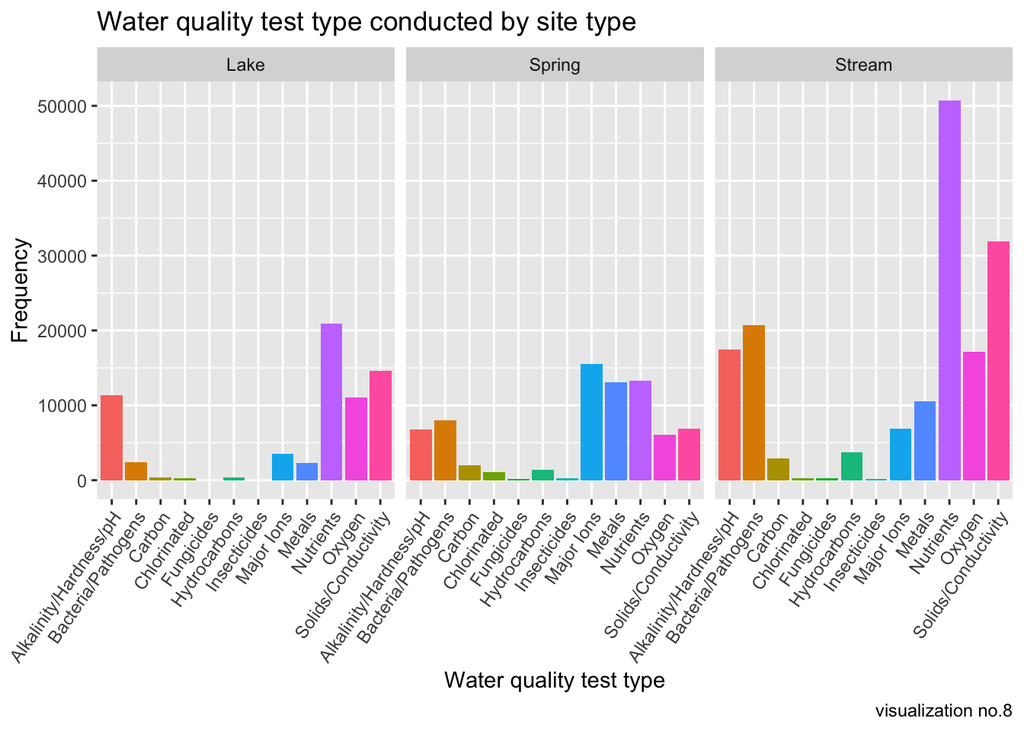

```r
water_quality_sampling_data_tidy |>
    filter(SITE_TYPE %in% c('Spring', 'Lake', 'Stream')) |>
    ggplot() +
        geom_bar(aes(x = PARAM_TYPE, fill = PARAM_TYPE)) +
        labs(title = 'Water quality test type conducted by site type',
             x = 'Water quality test type',
             y = 'Frequency',
             caption = 'visualization no.8') +
        theme(legend.position='none', axis.text.x = element_text(angle = 55, hjust = 1)) +
        facet_wrap(~SITE_TYPE)
```

## 4) Discussion

We also found that the water quality, in terms of dissolved oxygen, of the watersheds Lake Austin, Lake Travis, and Lady Bird Lake changed in volatile manners over the recorded years based on the visualizations 5-7. The concentration of dissolved oxygen has a daily/seasonal cycle, and is also affected by temperature which could explain the volatile nature of the dissolved oxygen concentrations for these watersheds across the years. The dissolved oxygen concentration can also tell us about the ability of aquatic life to prosper and for the body of water to be allowed for recreational use.

Finally, we found that there is a difference between the type of water quality tests conducted/the number of tests conduced and the site type looking at the plot of the spread of number of tests and type of test conducted by site type in visualization 8. The stream site type had the greatest number of observations conducted, indicating that streams in Austin are one of the most rigorously tested site types. Springs had the second-highest number of observations. It is extremely important that a high number of observations is gathered for springs and streams (and all bodies of water the city of Austin sources from) as it is often a source of drinking water or recreational use. Testing for contaminants is imperative to ensure the health of the greater Austin population. Springs are a source of freshwater, which only makes up 3% of the earth’s water supply. It is important for us to maintain springs so that we do not reduce this already small percentage.

Our findings showcase the importance of being aware of water quality across the different bodies of water in Austin. Many locals enjoy the natural springs and pools that Austin has to offer. Fortunately, in our findings in research question one, we discovered that Austin maintains safe levels of the four main nutrients in lakes, springs, and streams. Dissolved oxygen levels tend to be quite volatile, but the median and IQR are healthy. Austin has collected a significant amount of samples for each site type, but we encourage them to increase this in future years, especially for springs, so that data is more consistent, trends are more defined and complete data analysis is more readily conducted. Our results convey for the most part that Austin has a clean and healthy supply of water for its users to drink from and enjoy on hot summer days.

## 5) Reflection, acknowledgements, and references

Some parts that were challenging about this project were the tidying process of the data and thinking about the best way to visualize the data. We had to determine the best variables to use for our data and remove the columns that weren’t relevant to our research questions due to the sheer volume of observations included in this dataset. Initially, when we tried to visualize our data, there were too many observations to view the relationship between variables, especially with outliers. By filtering out certain variables and focusing on a specific number of site types and parameters, we could clearly see the relationships in the data.

Austine worked with cleaning the original dataset, and visualizing the data as well. GraceAnne and Seojin worked on analyzing the data and visualizations, and creating the presentation. We would like to thank the City of Austin for providing the water quality sampling data set for us to explore, and our professor Layla Guyot for giving us an opportunity to do this data analysis project.

Citations: https://www.austintexas.gov/department/water-quality-reports